# JIBE Trip validation: Melbourne

Marina Berdikhanova, Qin Zhang, Steve Pemberton, Carl Higgs

2025-07-10

## Load baseline trips.csv and VISTA trips

```r
## Select model outputs to validate (e.g. Melbourne model outputs of trips.csv and pp_2021.csv, respectively)
trips_file <- file.choose() # e.g. trips.csv
trips_ref <- trips_file %>% fread()
cat("Loaded trips file: ", trips_file, "\n")
```

```
## Loaded trips file:  D:\projects\jibe\melbourne\scenOutput_2025-07-10_MitoOnly_updatedMicrodestinations\trips.csv
```

```r
pp_file <- file.choose() # e.g. pp_2018.csv
pp_ref <- pp_file %>% fread()
cat("Loaded persons file: ", pp_file, "\n")
```

```
## Loaded persons file:  D:\projects\jibe\melbourne\microData\pp_2018.csv
```

```r
## Select reference survey data (e.g. VISTA trips and persons data; T_VISTA_1220_LGA_V1.csv and P_VISTA_1220_LGA_V1.csv
trips_vista_file <- file.choose() # e.g. T_VISTA_1220_Coord.csv
trips_vista <- trips_vista_file %>% fread()
cat("Loaded VISTA trips file: ", trips_vista_file, "\n")
```

```
## Loaded VISTA trips file:  C:\Users\E33390\OneDrive - RMIT University\DOT_VISTA\T_VISTA_1220_Coord.csv
```

```r
pp_vista_file <- file.choose() # e.g. P_VISTA_1220_Coord.csv
pp_vista <- pp_vista_file %>% fread()
cat("Loaded VISTA persons file: ", pp_vista_file, "\n")
```

```
## Loaded VISTA persons file:  C:\Users\E33390\OneDrive - RMIT University\DOT_VISTA\P_VISTA_1220_Coord.csv
```

```r
hh_vista_file <- file.choose() # e.g. H_VISTA_1220_Coord.csv
hh_vista <- hh_vista_file %>% fread()
cat("Loaded VISTA households file: ", hh_vista_file, "\n")
```

```
## Loaded VISTA households file:  C:\Users\E33390\OneDrive - RMIT University\DOT_VISTA\H_VISTA_1220_Coord.csv
```

## Data Preparation

Note that 1. For baseline data, home-based trips and RRT are factored/weighted by 2

2. Since VISTA is a one-day diary, all trips are factored/weighted by 7, to match the JIBE model full-week modelling approach.

3. To be consistent with trip-based model, return trips (e.g. work to home) are dropped from VISTA. Therefore, home-based trips and RRT in VISTA are also factored/weighted by 2
4. Trips that either origin or destination outside Greater Melbourne Boundary are dropped from VISTA dataset
5. VISTA includes all ages (unlike TRADS, which does not include kids under 5 years old)

```r
trips_ref <- trips_ref %>%
  mutate(scenario = "Baseline")

trips_ref <- trips_ref %>%
  mutate(mode = case_when(
           mode == "autoDriver" ~ "Driving Car",
           mode == "autoPassenger" ~ "Car Passenger",
           mode == "pt" ~ "Public Transport",
           mode == "walk" ~ "Walking",
           mode == "bicycle" ~ "Cycling",
           TRUE ~ "Other"),
         t.factor = if_else(t.purpose %in% c("HBW",
                                           "HBE",
                                           "HBA",
                                           "HBS",
                                           "HBR",
                                           "HBO",
                                           "RRT"), 2,1),
         time_walk = time_walk/60,
         time_bike = time_bike/60,
         time_auto = time_auto/60,
         time_pt = time_pt/60,
         time = case_when(mode=="Cycling"~time_bike,
                          mode=="Walking"~time_walk,
                          mode=="Public Transport"~time_pt,
                          mode=="Driving Car"~time_auto,
                          mode=="Car Passenger"~time_auto),
         dist = case_when(mode=="Cycling"~t.distance_bike,
                          mode=="Walking"~t.distance_walk,
                          mode=="Public Transport"~t.distance_auto,
                          mode=="Driving Car"~t.distance_auto,
                          mode=="Car Passenger"~t.distance_auto),
         time_factored = time * t.factor,
         dist_factored = dist * t.factor,
         t.weight = 1,
         p.weight = 1,
         # convert ID to character, for consistency with VISTA person IDs
         p.ID = as.character(p.ID)) %>%
  select(p.ID, t.purpose, time, time_factored, dist, dist_factored, mode,
         scenario, t.factor, t.weight, p.weight)

trips_scenario_vista <- trips_vista %>%
  mutate(scenario = "VISTA")


# VISTA-version specific fields for weights and areas
# 2025-02-26 confirmed that wdtripwgt_sa3 and wdperswgt_sa3 fields exist in the VISTA trips and persons data
# the 'else' option of using LGA weights is used for test purposes with open data lacking the SA3 weights
# Note: origin and destination variables are different; the full dataset has them lower case, but also has
# SA2 and SA3 in addition to SA4.
if ("wdtripwgt_sa3" %in% names(trips_vista) & "wetripwgt_sa3" %in% names(trips_vista) &
    "wdperswgt_sa3" %in% names(pp_vista) & "weperswgt_sa3" %in% names(pp_vista)) {
  wdtripwgt <- "wdtripwgt_sa3"
  wetripwgt <- "wetripwgt_sa3"
  wdperswgt <- "wdperswgt_sa3"
  weperswgt <- "weperswgt_sa3"
  origin_area <- "origsa4_name"
  destination_area <- "destsa4_name"
} else {
  wdtripwgt <- "wdtripwgt_LGA"
  wetripwgt <- "wetripwgt_LGA"
  wdperswgt <- "wdperswgt_LGA"
  weperswgt <- "weperswgt_LGA"
  origin_area <- "origSA4_name"
  destination_area <- "destSA4_name"
}


# exclude trips outside Greater Melbourne [CARL - please check that this works as intended:
# in particular, that the origSA4_name and destSA4_name fields are present, and that the filter
# succeeds in picking up trips from all 9 of the specified SA4s]
trips_scenario_vista <- trips_scenario_vista %>%
  filter(!!sym(origin_area) %in% c("Melbourne - Inner", "Melbourne - Inner East",
                             "Melbourne - Inner South", "Melbourne - North East",
                             "Melbourne - North West", "Melbourne - Outer East",
                             "Melbourne - South East", "Melbourne - West",
                             "Mornington Peninsula") &
           !!sym(destination_area) %in% c("Melbourne - Inner", "Melbourne - Inner East",
                             "Melbourne - Inner South", "Melbourne - North East",
                             "Melbourne - North West", "Melbourne - Outer East",
                             "Melbourne - South East", "Melbourne - West",
                             "Mornington Peninsula"))

# add purpose to VISTA trips (see Carl's work at https://github.com/jibeproject/Melbourne-Mode-Choice/blob/main/JIBE_Melbourne_Mode_Choice.md#jibe-melbourne-mode-choice-preparation-and-analysis)

# clean trip purposes, by replacing purpose/place with 'work related' where
# one is specified and the other is missing
trips_scenario_vista <- trips_scenario_vista %>%
  mutate(origplace1 = ifelse((is.na(origplace1) | str_detect(origplace1, "Unknown")) &
                               origpurp1 == "Work Related",
                             "Workplace",
                             origplace1),
         destplace1 = ifelse((is.na(destplace1) | str_detect(destplace1, "Unknown")) &
                               destpurp1 == "Work Related",
                             "Workplace",
                             destplace1),
         origpurp1 = ifelse((is.na(origpurp1) | str_detect(origpurp1, "Unknown")) &
                              origplace1 == "Workplace",
                            "Work Related",
                            origpurp1),
         destpurp1 = ifelse((is.na(destpurp1) | str_detect(destpurp1, "Unknown")) &
                              destplace1 == "Workplace",
                            "Work Related",
                            destpurp1))

# assign purpose
trips_scenario_vista <- trips_scenario_vista %>%
  mutate(purpose = case_when(
    origpurp2 == "Employer's Business" | destpurp2 == "Employer's Business" ~ "business",
    origpurp1 %in% c("Unknown Purpose (at start of day)", "Not Stated") |
      destpurp1 %in% c("NA", "Not Stated")                ~ "unknown",
    origpurp1 == "At Home" & destpurp1 == "At or Go Home" ~ "RRT",
    # trips from home are HBx, with 'x' based on destination
    origpurp1 == "At Home" ~ case_when(
      destpurp1 == "Work Related"                         ~ "HBW",
      destpurp1 == "Education"                            ~ "HBE",
      destpurp1 == "Buy Something"                        ~ "HBS",
      destpurp1 == "Recreational"                         ~ "HBR",
      destpurp1 == "Other Purpose"                        ~ "HBO",
      destpurp1 %in% c("Accompany Someone","Pick-up or Drop-off Someone") ~ "HBA",
      # classify remaining trips from home using place information if clearer than purpose
      destplace1 == "Workplace"                           ~ "HBW",
      destplace1 == "Place of Education"                  ~ "HBE",
      destplace1 == "Shops"                               ~ "HBS",
      destplace1 %in% c("Recreational Place","Natural Feature", "Social Place") ~ "HBR",
      # all other trips from home are HBO
      TRUE                                                ~ "HBO"
    ),
    # trips to home are NA
    destpurp1 == "At or Go Home"                          ~ "NA",
    origpurp1 == "Work Related" | destpurp1 == "Work Related" ~ "NHBW",
    # default for trips that are neither from home nor to home
    TRUE                                                  ~ "NHBO"
  ))
```

```r
# Inspect modes
# cat(trips_scenario_vista$linkmode %>% unique() %>% sort())
## In full VISTA, the following modes were present:.groups
## "Bicycle","Jogging","Mobility Scooter","Motorcycle","Other","Public Bus","School Bus","Taxi","Train","Tram","Vehicle Driver","Vehicle Passenger","Walking"

trips_scenario_vista <- trips_scenario_vista %>%
  left_join(pp_vista, by = "persid") %>%
  filter(!purpose%in%c("NA","business","unknown"))%>%
  mutate(
    mode = case_when(
      linkmode == "Vehicle Driver"                 ~ "Driving Car",
      linkmode == "Vehicle Passenger"              ~ "Car Passenger",
      linkmode %in% c("Public Bus", "School Bus",
                      "Train", "Tram")             ~ "Public Transport",
      linkmode == "Walking"                        ~ "Walking",
      linkmode == "Bicycle"                        ~ "Cycling",
      # 'Other' covers Jogging, Mobility Scooter, Motorcycle, Other, and Taxi in VISTA 2012-20
      TRUE                                         ~ "Other"
    ),
    t.factor = if_else(purpose %in% c("HBW",
                                      "HBE",
                                      "HBA",
                                      "HBS",
                                      "HBR",
                                      "HBO",
                                      "RRT"), 2*7, 1*7),
    # [SP note: alternative version of time and dist based on time/dist
    # specified in the VISTA data] [CARL - please don't change anything here at this stage:
    # relates to query below for Qin and Corin]
    time = triptime / 60,  # time converted from minutes to hours
    dist = cumdist,  # distance in km

    # # [SP note: will the version of VISTA have been pre-processed to include
    # # these 'bike_fast_time' etc fields? If so, uncomment (and delete above)]
    # # [CARL - this is a query for Qin and Corin; no need to do anything with this
    # # commented-out code block at the moment]
    # time = case_when(mode == "Cycling"          ~ bike_fast_time/3600,
    #                  mode == "Walking"          ~ walk_fast_time/3600,
    #                  mode == "Public Transport" ~ pt_time/3600,
    #                  mode == "Driving Car"      ~ car_congested_time/3600,
    #                  mode == "Car Passenger"    ~ car_congested_time/3600),
    # dist = case_when(mode == "Cycling"          ~ bike_fast_dist/1000,
    #                  mode == "Walking"          ~ walk_fast_dist/1000,
    #                  mode == "Public Transport" ~ pt_dist/1000,
    #                  mode == "Driving Car"      ~ car_congested_dist/1000,
    #                  mode == "Car Passenger"    ~ car_congested_dist/1000),

    time_factored = time * t.factor,
    dist_factored = dist * t.factor,

    # Lines below assume there are weekday ('wd') and weekend ('we') weights, with only
    # the right one specified for the relevant day and the other one blank or NA].
    # [2025-02-26 - confirms this assumption holds for full VISTA 2012-20 data)
    t.weight = ifelse(is.na(.data[[wdtripwgt]]) | .data[[wdtripwgt]] == "",
                      .data[[wetripwgt]], .data[[wdtripwgt]]),
    p.weight = ifelse(is.na(.data[[wdperswgt]]) | .data[[wdperswgt]] == "",
                      .data[[weperswgt]], .data[[wdperswgt]]),
    # convert weights to numeric format
    t.weight = as.numeric(gsub(",", "", t.weight)),
    p.weight = as.numeric(gsub(",", "", p.weight))) %>%

  filter(!mode %in% c("Other"))%>%
  select(p.ID = persid, t.purpose = purpose, time, time_factored, dist,
         dist_factored, mode, scenario, t.factor, t.weight, p.weight)

trips_scenario_vista_noWeight = trips_scenario_vista %>%
  mutate(t.weight = 1,
         p.weight = 1,
         scenario = "VISTA_noWeight")

trips <- bind_rows(trips_ref, trips_scenario_vista, trips_scenario_vista_noWeight)%>%
  mutate(mode = factor(mode, levels = c("Driving Car",
                                        "Car Passenger",
                                        "Public Transport",
                                        "Walking",
                                        "Cycling",
                                        "Other")),
         t.purpose = case_when(
           t.purpose == "HBW" ~ "Home-based-work",
           t.purpose == "HBE" ~ "Home-based-education",
           t.purpose == "HBA" ~ "Home-based-accompanying",
           t.purpose == "HBS" ~ "Home-based-shopping",
           t.purpose == "HBR" ~ "Home-based-recreation",
           t.purpose == "HBO" ~ "Home-based-other",
           t.purpose == "NHBO" ~ "Non-home-based-other",
           t.purpose == "NHBW" ~ "Non-home-based-work",
           t.purpose == "RRT" ~ "Recreational round trip",
           TRUE ~ NA_character_),
         t.purpose = factor(t.purpose, levels = c("Home-based-work",
                                                  "Home-based-education",
                                                  "Home-based-accompanying",
                                                  "Home-based-shopping",
                                                  "Home-based-recreation",
                                                  "Home-based-other",
                                                  "Non-home-based-other",
                                                  "Non-home-based-work",
                                                  "Recreational round trip")))

## 'trips' fields and data structure in sample open VISTA data
# > str(trips)
# Classes ‘data.table’ and 'data.frame':    22702179 obs. of  11 variables:
#  $ p.ID         : chr  "5" "5" "5" "5" ...
#  $ t.purpose    : Factor w/ 9 levels "Home-based-work",..: 1 1 1 1 1 1 1 1 1 1 ...
#  $ time         : num  0.162 0.162 0.162 0.162 0.178 ...
#  $ time_factored: num  0.323 0.323 0.323 0.323 0.355 ...
#  $ dist         : num  5.34 5.34 5.34 5.34 7.08 ...
#  $ dist_factored: num  10.7 10.7 10.7 10.7 14.2 ...
#  $ mode         : Factor w/ 6 levels "Driving Car",..: 1 1 1 1 1 1 4 4 4 4 ...
#  $ scenario     : chr  "Baseline" "Baseline" "Baseline" "Baseline" ...
#  $ t.factor     : num  2 2 2 2 2 2 2 2 2 2 ...
#  $ t.weight     : num  1 1 1 1 1 1 1 1 1 1 ...
#  $ p.weight     : num  1 1 1 1 1 1 1 1 1 1 ...
#  - attr(*, ".internal.selfref")=<externalptr>
```

```r
## 'trips' fields and data structure
# str(trips)
### Full VISTA 2012-20:
## Classes 'data.table' and 'data.frame':   35417074 obs. of  11 variables:
##  $ p.ID         : chr  "520797" "520797" "520797" "520797" ...
##  $ t.purpose    : Factor w/ 9 levels "Home-based-work",..: 1 1 1 1 1 1 1 1 1 1 ...
##  $ time         : num  0.184 0.184 0.184 0.184 0.184 ...
##  $ time_factored: num  0.368 0.368 0.368 0.368 0.368 ...
##  $ dist         : num  2.26 2.26 2.26 2.26 2.26 ...
##  $ dist_factored: num  4.53 4.53 4.53 4.53 4.53 ...
##  $ mode         : Factor w/ 6 levels "Driving Car",..: 3 3 3 3 3 3 1 1 1 1 ...
##  $ scenario     : chr  "Baseline" "Baseline" "Baseline" "Baseline" ...
##  $ t.factor     : num  2 2 2 2 2 2 2 2 2 2 ...
##  $ t.weight     : num  1 1 1 1 1 1 1 1 1 1 ...
##  $ p.weight     : num  1 1 1 1 1 1 1 1 1 1 ...
##  - attr(*, ".internal.selfref")=<externalptr>
```

# Diagnostics

## Summary of NA, infinite, and zero values by mode and scenario

```r
diagnostics <- trips %>%
  group_by(scenario, mode) %>%
  summarise(
    n = n(),
    n_time_na = sum(is.na(time)),
    n_time_inf = sum(is.infinite(time)),
    n_time_zero = sum(time == 0, na.rm = TRUE),
    n_dist_na = sum(is.na(dist)),
    n_dist_inf = sum(is.infinite(dist)),
    n_dist_zero = sum(dist == 0, na.rm = TRUE)
  )

diagnostics %>%
  gt() %>%
  tab_header(title = "Summary of NA, Infinite, and Zero Values by Mode and Scenario") %>%
  cols_label(
    n = "Total Trips",
    n_time_na = "NA Time",
    n_time_inf = "Infinite Time",
    n_time_zero = "Zero Time",
    n_dist_na = "NA Distance",
    n_dist_inf = "Infinite Distance",
    n_dist_zero = "Zero Distance"
  )
```

Summary of NA, Infinite, and Zero Values by Mode and Scenario

| mode | Total Trips | NA Time | Infinite Time | Zero Time | NA Distance | Infinite Distance | Zero Distance |
| --- | --- | --- | --- | --- | --- | --- | --- |
| Baseline |  |  |  |  |  |  |  |
| Driving Car | 15973188 | 0 | 0 | 174 | 0 | 0 | 174 |
| Car Passenger | 9430747 | 0 | 0 | 124 | 0 | 0 | 124 |
| Public Transport | 2358151 | 0 | 67 | 0 | 0 | 0 | 30 |
| Walking | 6290487 | 0 | 0 | 1699 | 0 | 0 | 1699 |
| Cycling | 1144291 | 0 | 0 | 33 | 0 | 0 | 33 |
| VISTA |  |  |  |  |  |  |  |
| Driving Car | 55682 | 0 | 0 | 0 | 0 | 0 | 1 |
| Car Passenger | 26354 | 0 | 0 | 0 | 0 | 0 | 0 |
| Public Transport | 7643 | 0 | 0 | 0 | 0 | 0 | 0 |
| Walking | 18672 | 0 | 0 | 0 | 0 | 0 | 14 |
| Cycling | 1754 | 0 | 0 | 0 | 0 | 0 | 0 |
| VISTA_noWeight |  |  |  |  |  |  |  |
| Driving Car | 55682 | 0 | 0 | 0 | 0 | 0 | 1 |
| Car Passenger | 26354 | 0 | 0 | 0 | 0 | 0 | 0 |
| Public Transport | 7643 | 0 | 0 | 0 | 0 | 0 | 0 |
| Walking | 18672 | 0 | 0 | 0 | 0 | 0 | 14 |
| Cycling | 1754 | 0 | 0 | 0 | 0 | 0 | 0 |

A fraction of trips in the baseline scenario had zero distance and/or time across the various modes. Mostly, these were for walking (1699/6290487 = 0.027%), which may be a reflection of the 14/18,672 VISTA walking trips (0.075%) that had zero recorded distance; likewise for zero distance driving trips (about 0.001% in both Vista and Baseline). Additionally, there were 67 public transport trips recorded with infinite values for time.

Causes of outlying values should be considered. They may cause issues with the following diagnostic plots. For example, average public transport trip time for Baseline will be infinite if the 67 inifinite values (0.003%) are not excluded from that calculation.

For the following plots, we will exclude these outlying trips with zero distance or time, and infinite values for time and distance.

```r
trips <- trips %>%
  filter(
    dist > 0,
    time > 0,
    !is.infinite(time),
    !is.infinite(dist)
  )
```

## Null trip weights in VISTA data

```r
# check for null weights in VISTA data; there are a few -- we'll count them so we can discuss
na_weight_summary <- trips %>%
  group_by(scenario) %>%
  summarise(
    total_trips = n(),
    na_weights = sum(is.na(t.weight)),
    prop_na_weights = round(sum(is.na(t.weight)) / n() * 100, 4),
    .groups = 'drop'
  )

na_weight_summary %>%
  gt() %>%
  tab_header(
    title = "Summary of NA Trip Weights by Scenario"
  ) %>%
  cols_label(
    scenario = "Scenario",
    total_trips = "Total Trips",
    na_weights = "NA Weights",
    prop_na_weights = "% NA Weights"
  ) %>%
  fmt_number(
    columns = c(total_trips, na_weights),
    decimals = 0,
    use_seps = TRUE
  ) %>%
  fmt_number(
    columns = prop_na_weights,
    decimals = 4
  )
```

Summary of NA Trip Weights by Scenario

| Scenario | Total Trips | NA Weights | % NA Weights |
| --- | --- | --- | --- |
| Baseline | 35,194,737 | 0 | 0.0000 |
| VISTA | 110,090 | 113 | 0.1026 |
| VISTA_noWeight | 110,090 | 0 | 0.0000 |

113/110105 (0.1%) of trips in the full VISTA 2012-20 data have null trip weights. These records will be excluded from the following diagnostics plots.

```r
trips <- trips %>%
  filter(!is.na(t.weight))
```

## Key Figures

```r
pop_baseline = nrow(pp_ref)
pop_vista = sum(as.numeric(gsub(",", "", pp_vista[[wdperswgt]])), na.rm = T) +
  sum(as.numeric(gsub(",", "", pp_vista[[weperswgt]])), na.rm = T)
pop_vista_noWeight = nrow(pp_vista)

summary = trips %>% group_by(scenario) %>% summarise(trips=sum(t.factor*t.weight, na.rm=TRUE))

summary = summary %>%
  mutate(pop = c(pop_baseline, pop_vista, pop_vista_noWeight),
         avgTrip = trips/pop)
```

```r
rm(trips_ref, trips_scenario_vista, trips_scenario_vista_noWeight, pp_ref, pp_vista, trips_vista)
```

Key Figures

| scenario | Total Trips over a week | Total population | Weekly Trip Rates Per Person |
| --- | --- | --- | --- |
| Baseline | 62259451 | 4174056 | 14.91582 |
| VISTA | 183193029 | 10776247 | 16.99971 |
| VISTA_noWeight | 1297688 | 82118 | 15.80272 |

## Trips by purpose

```r
summary = trips%>%
  group_by(scenario,t.purpose)%>%
  summarise(count=sum(t.factor*t.weight, na.rm=TRUE))%>%
  mutate(percent = count/sum(count)*100)
```

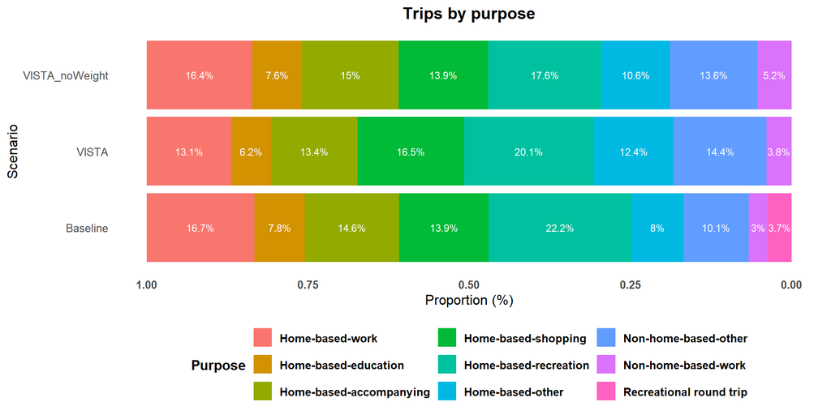

## Trips by distance bracket

```r
trips$distance_bracket <- cut(
  trips$dist,
  breaks = c(0, 1, 3, 5, 10, 20, 40, Inf),
  labels = c("0-1", "1-3", "3-5", "5-10", "10-20", "20-40", "40+"),
  right = FALSE)

summary <- trips %>%
  group_by(scenario, distance_bracket) %>%
  summarise(count = sum(t.factor*t.weight, na.rm=TRUE)) %>%
  mutate(percent = count / sum(count) * 100)
```

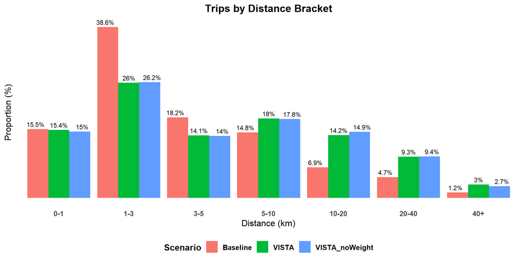

## Trips by distance bracket by mode

```r
trips$distance_bracket <- cut(
  trips$dist,
  breaks = c(0, 1, 3, 5, 10, 20, 40, Inf),
  labels = c("0-1", "1-3", "3-5", "5-10", "10-20", "20-40", "40+"),
  right = FALSE)

summary <- trips %>%
  group_by(distance_bracket, mode, scenario) %>%
  summarise(count = sum(t.factor*t.weight, na.rm=TRUE), .groups = 'drop') %>%
  group_by(mode, scenario) %>%
  mutate(percent = count / sum(count) * 100)
```

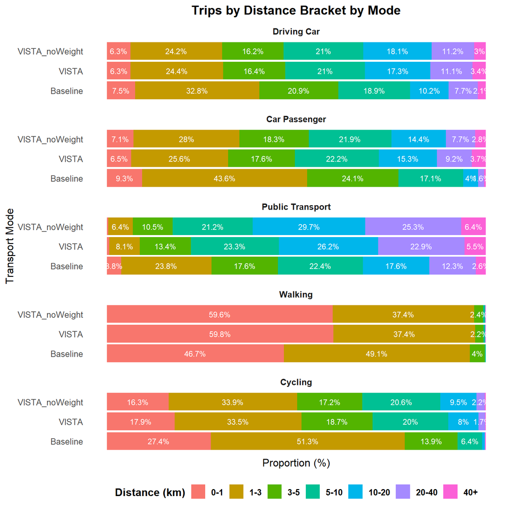

## Trip Length Distribution by Transport Mode

[figure not shown]

## Median Trip Distance Comparison by Mode and Scenario

```r
# Calculate median distances by scenario and mode
median_summary <- trips %>%
  group_by(scenario, mode) %>%
  summarise(
    median_dist_km = median(dist, na.rm = TRUE),
    median_dist_m = median(dist * 1000, na.rm = TRUE),
    .groups = 'drop'
  )

# Reshape to compare scenarios
median_comparison <- median_summary %>%
  select(scenario, mode, median_dist_km) %>%
  pivot_wider(names_from = scenario, values_from = median_dist_km) %>%
  mutate(
    diff_baseline_vista = Baseline - VISTA,
    diff_baseline_vista_noweight = Baseline - VISTA_noWeight,
    pct_diff_baseline_vista = round((Baseline - VISTA) / VISTA * 100, 1),
    pct_diff_baseline_vista_noweight = round((Baseline - VISTA_noWeight) / VISTA_noWeight * 100, 1)
  )

# Display formatted table
median_comparison %>%
  gt() %>%
  tab_header(
    title = "Median Trip Distance Comparison by Mode",
    subtitle = "Distances in kilometers"
  ) %>%
  cols_label(
    mode = "Mode",
    Baseline = "Baseline",
    VISTA = "VISTA",
    VISTA_noWeight = "VISTA (No Weight)",
    diff_baseline_vista = "Diff: Baseline - VISTA",
    diff_baseline_vista_noweight = "Diff: Baseline - VISTA (No Weight)",
    pct_diff_baseline_vista = "% Diff: Baseline vs VISTA",
    pct_diff_baseline_vista_noweight = "% Diff: Baseline vs VISTA (No Weight)"
  ) %>%
  fmt_number(
    columns = c(Baseline, VISTA, VISTA_noWeight, diff_baseline_vista, diff_baseline_vista_noweight),
    decimals = 2
  ) %>%
  fmt_number(
    columns = c(pct_diff_baseline_vista, pct_diff_baseline_vista_noweight),
    decimals = 1,
    suffix = "%"
  ) %>%
  tab_style(
    style = cell_fill(color = "lightblue"),
    locations = cells_body(
      columns = c(pct_diff_baseline_vista, pct_diff_baseline_vista_noweight),
      rows = abs(pct_diff_baseline_vista) > 20 | abs(pct_diff_baseline_vista_noweight) > 20
    )
  )
```

Median Trip Distance Comparison by Mode

Distances in kilometers

| Mode | Baseline | VISTA | VISTA (No Weight) | Diff: Baseline - VISTA | Diff: Baseline - VISTA (No Weight) | % Diff: Baseline vs VISTA | % Diff: Baseline vs VISTA (No Weight) |
| --- | --- | --- | --- | --- | --- | --- | --- |
| Driving Car | 3.61 | 5.42 | 5.42 | −1.81 | −1.81 | −33.4 | −33.4 |
| Car Passenger | 2.78 | 4.55 | 4.56 | −1.77 | −1.78 | −38.9 | −39.0 |
| Public Transport | 5.41 | 12.96 | 12.96 | −7.55 | −7.55 | −58.3 | −58.3 |
| Walking | 1.04 | 0.76 | 0.76 | 0.28 | 0.28 | 36.8 | 36.8 |
| Cycling | 1.61 | 2.99 | 2.99 | −1.37 | −1.37 | −46.0 | −46.0 |

## Overall Mode share

```r
summary <- trips %>%
  group_by(scenario,mode) %>%
  summarise(count = sum(t.factor*t.weight, na.rm=TRUE)) %>%
  mutate(percent = count / sum(count) * 100)
```

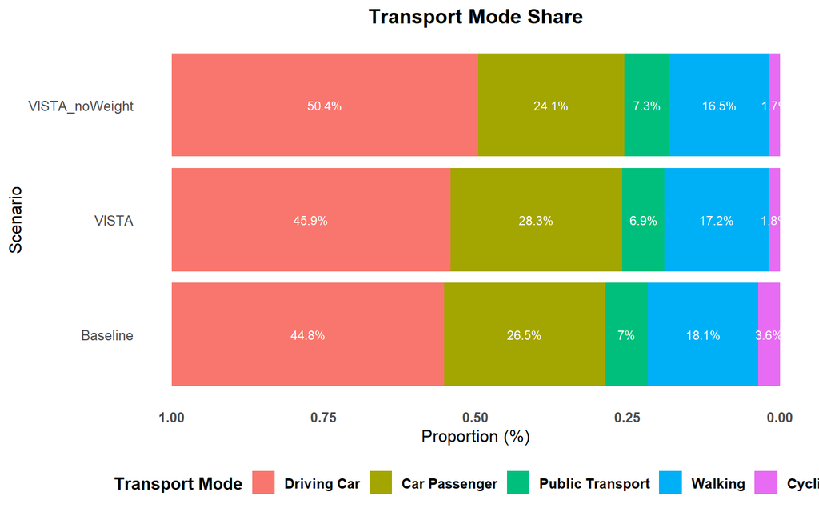

## Mode share by distance bracket

```r
trips$distance_bracket <- cut(
  trips$dist,
  breaks = c(0, 1, 3, 5, 10, 20, 40, Inf),
  labels = c("0-1", "1-3", "3-5", "5-10", "10-20", "20-40", "40+"),
  right = FALSE)

summary <- trips %>%
  group_by(distance_bracket, mode, scenario) %>%
  summarise(count = sum(t.factor*t.weight, na.rm=TRUE), .groups = 'drop') %>%
  group_by(distance_bracket, scenario) %>%
  mutate(percent = count / sum(count) * 100)
```

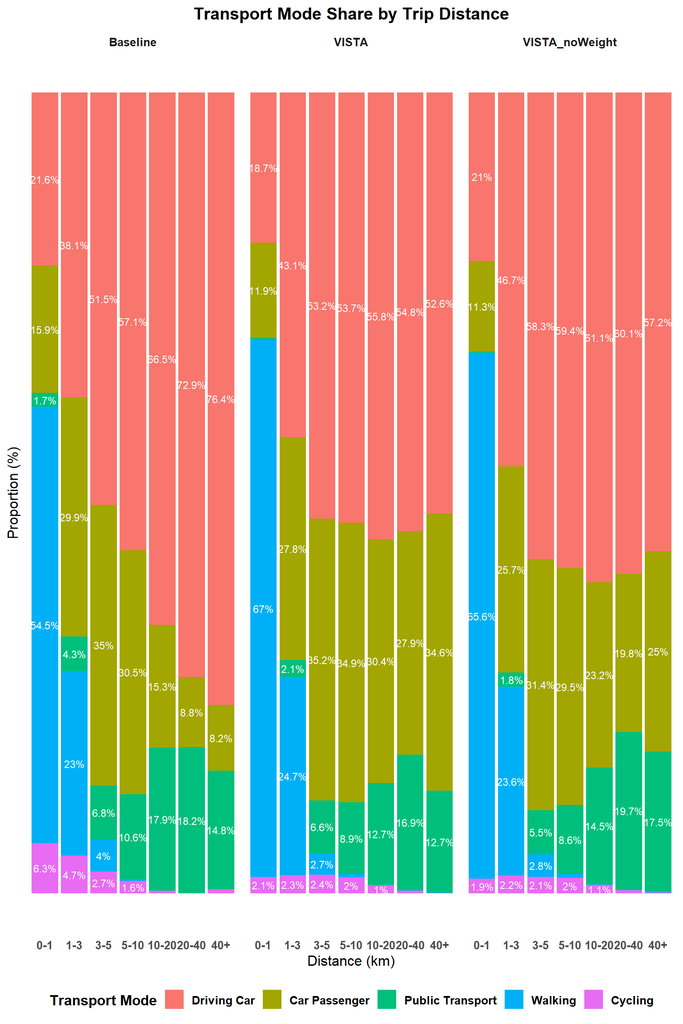

## Average Weekly Distance Travelled Per Person

Note that

1. Distances of all modes are routed distances resulting from MATSim. For VISTA trips, the centroids of origin mesh block and destination mesh block are used for routing. *[SP note: to be confirmed that these routed distances will be calculated for VISTA]
2. In MATSim, PT is time-based routing. So for the plots, we assume PT distances is equal to Car routed distance

```r
summary=trips%>%
  group_by(p.ID, mode,scenario)%>%
  summarise(dist=sum(dist_factored*p.weight, na.rm=TRUE))

summary=summary%>%
  group_by(mode, scenario)%>%
  summarise(totalDist=sum(dist)) %>%
  mutate(avgDist = case_when(scenario == "Baseline" ~ totalDist/pop_baseline,
                             scenario == "VISTA" ~ totalDist/pop_vista,
                             scenario == "VISTA_noWeight" ~ totalDist/pop_vista_noWeight))
```

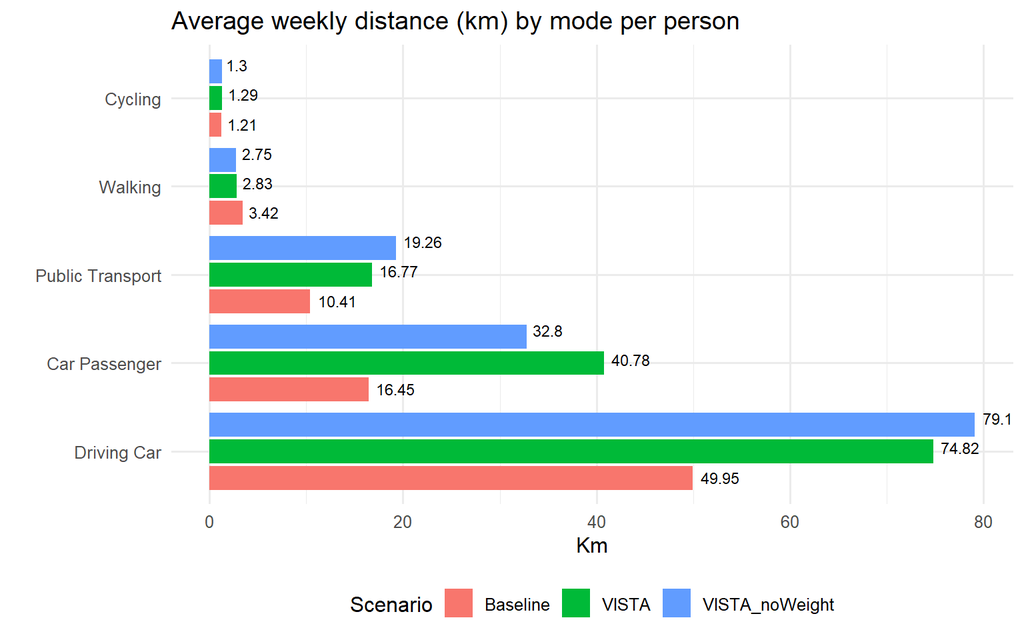

## Average Weekly Time Travelled Per Person

Note that

1. Travel time of all modes are routed travel time resulting from MATSim. For VISTA trips, the centroids of origin mesh block and destination mesh block are used for routing. *[SP note: to be confirmed that (1) these routed distances will be calculated for VISTA]*
2. PT travel time includes access, egress time, in-vehicle time, waiting time and transfer time.
3. Car travel time are routed on congested network

```r
summary=trips%>%
  group_by(p.ID, mode,scenario)%>%
  summarise(time=sum(time_factored*p.weight, na.rm=TRUE))

summary=summary%>%
  group_by(mode, scenario)%>%
  summarise(totalTime=sum(time)) %>%
  mutate(avgTime = case_when(scenario == "Baseline" ~ totalTime/pop_baseline*60,
                             scenario == "VISTA" ~ totalTime/pop_vista*60,
                             scenario == "VISTA_noWeight" ~ totalTime/pop_vista_noWeight*60))
```

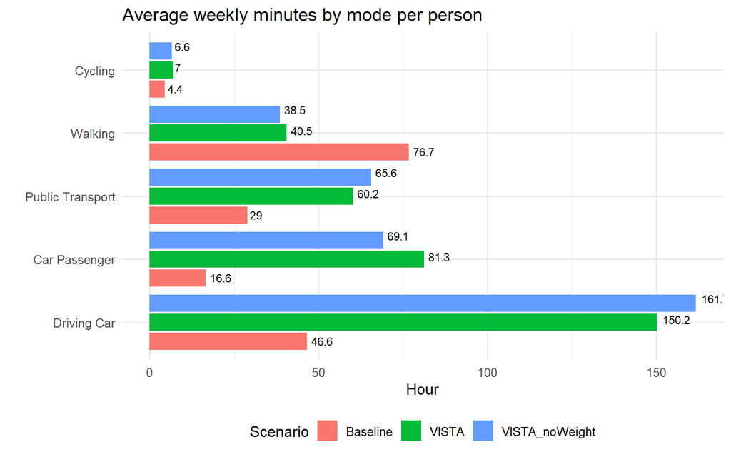

[figure not shown]

# Observations

A small number of trip records (< 0.1% ) were excluded from diagnostic analysis due to zero distance or time, or infinite values for time and distance. These exclusions are unlikely to significantly affect the overall analysis. Likewise, a small number of trip records (0.1%) were excluded due to null trip weights in the VISTA data.

Considering trips by purpose, the Baseline scenario proportions closely resemble those of the VISTA_noWeight dataset, albeit with more home-based recreation trips (22.2% compared to 17.6%) and fewer home-based-other and non-home based other trips (18.1% compared to 24.2%, as combined ‘other’).

For walking, the baseline scenario underestimates trips under 1000m distance (47%, compared to 60%) while overestimating those from 1 to 3 km (49.1% compared to 37.4%). For cycling, the baseline scenario overestimates trips under 1000m distance (27% compared to 17%) and those from 1 to 3 km (51.3% compared to 33.5%), while longer distance cycling trips are underestimated. This may have implications for mode shift estimates in the cycling intervention, where greater potential for shifting from driving to cycling may be possible for shorter trips.

The distribution of trips lengths is underestimated for all modes relative to the VISTA survey, with the exception of walking. This was particularly the case for public transport where the median trip distance was 5.4km in the Baseline scenario, less than half the VISTA median public transport distance of 12.96 km.

Mode share was approximately similar between the Baseline and VISTA scenarios; the VISTA_noWeight scenario had higher estimates for driving (50.4% compared to 44.8%), and lower for walking (16.5% compared to 18.1%). The Baseline scenario overestimated the proportion of cycling trips by a factor of approximately 2 (3.6% compared to approximatley 1.8% in both VISTA scenarios).

Walking was under-estimated, while cycling and driving were over-estimated for short trips of less than 1000m.

The average weekly distance for vehicle travel (driving or passenger) was underestimated in the Baseline scenario (for driving, 50km compared to approximately 75km+ for VISTA), as was the distance of public transport usage (10.4 km compared to more than 16km for VISTA scenarios). However, walking and cycling distance estimates were approximately similar (if a slight over-estimation in walking distance, 3.4km compared to 2.8km for VISTA).